# In-class exercise for Week 4-2

### 5. Adding and Removing Elements

Lists can have any number of elements. You can add elements using the `append` and `insert` functions and remove them with the `remove` function and `del` operator. Why are `append`, `insert` and `remove` *functions* and `del` an *operator*? The answer is a bit complicated, but in short `append`, `insert` and `remove` are specific to a `list`, `del` works on lists and other data types too so it's more generic.

#### 5-1 The `append` Function

The `append` function adds an item to the end of the list.

Let's add `Eat`, `Sleep`, `Program`, and `Repeat`

```python
todo_list2=[]
```

```python
print(todo_list2)
```

```
[]
```

```python
todo_list2.append("eat")
todo_list2.append("sleep")
todo_list2.append("program")
todo_list2.append("repeat")
print(todo_list2)
```

```
['eat', 'sleep', 'program', 'repeat']
```

#### 5-2 The `insert` Function

The `insert` function adds an element to the list in any place you like. Calling `insert` displaces existing elements which are moved to the next index. Think of it as them moving to the right. For example:

```python
todo_list2.insert(1,"game")
print(todo_list2)
```

```
['eat', 'game', 'sleep', 'program', 'repeat']
```

#### 5-3 The `del` Operator

Type in the example:

```python
del todo_list2[2]
print(todo_list2)
```

```
['eat', 'game', 'program', 'repeat']
```

#### 5-4 The `remove` Function

Try using the `remove` function in the next cell:

```python
todo_list2.remove("eat")
print(todo_list2)
```

```
['game', 'program', 'repeat']
```

```python
todo_list2.remove[2]
```

[output not shown]

#### 5-5 The `clear` Function

You delete *every* item in a list using the `clear()` function.

```python
todo_list2.clear()
print(todo_list2)
```

```
[]
```

#### 5-6 `split` and `join`: Converting Between Lists and Strings

Try using `split`:

```python
sentence=("Tony Stark is so handsome")
words=sentence.split()
print(words)
```

```
['Tony', 'Stark', 'is', 'so', 'handsome']
```

```python
type(words)
```

```
list
```

```python
sentence2=",".join(words)
print(sentence)
```

```
Tony Stark is so handsome
```

#### Question 2

Build your own To-do list

Create a list variable called `todo_list` with your own things to do.

```python
todo_list=["work","eat","sleep","travel"]
```

#### Question 3

Change one element of `todo_list`

```python
todo_list.append("party")
print(todo_list)
```

[output not shown]

#### Question 4

Print the third item in `todo_list`

```python
print(todo_list[2],todo_list[4])
```

```
sleep party
```

#### Question 5

Use the `append` function to add "Sleep" to the end of `todo_list`

```python
todo_list.append("sleep")
print(todo_list)
```

```
['work', 'eat', 'sleep', 'travel', 'party', 'party', 'party', 'party', 'sleep']
```

#### Question 6

Use the `del` operator to remove one element.

```python
del todo_list[0]
print(todo_list)
```

[output not shown]

#### Question 7

Use the `remove` function to remove "Sleep" from the `todo_list`

```python
todo_list.remove("sleep")
print(todo_list)
```

[output not shown]

#### Question 8

Use `insert` to insert "Read the Book" as the second element.

```python
todo_list.insert(1,"Read the book")
print(todo_list)
```

```
['travel', 'Read the book', 'party', 'party', 'party', 'party']
```

## 2. Bitwise

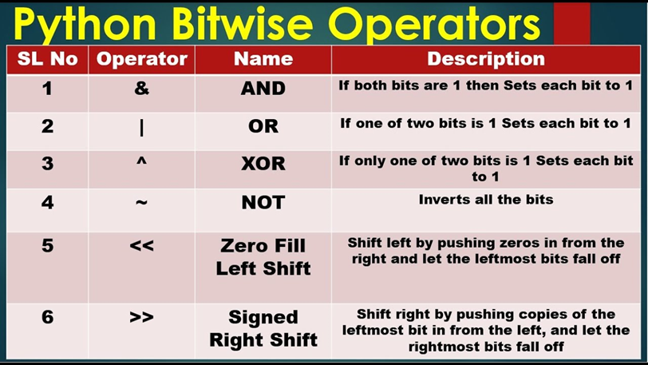

```python
bin(1)
```

```
'0b1'
```

```python
bin(2)
```

```
'0b10'
```

```python
bin(5)
```

```
'0b101'
```

```python
1&1
```

```
1
```

```python
1&0
```

```
0
```

```python
1|1
```

```
1
```

```python
1|0
```

```
1
```